# 都市内の住宅立地

岩田真一郎（神奈川大学経済学部）

2023-01-20作成，2023-01-20改訂

ここでは，都市経済学の基礎となる都市内の住宅立地の理論を学びながら，都市内の空間構造（土地利用）について理解します．ミクロ経済学で学ぶ無差別曲線と予算制約線を用いて都市内での地代や土地利用がどのように決まり，その決定要因である交通費や所得などの影響を考えていきます．

# 1 単一中心都市

都市経済学では，都市に居住する消費者がどのように住宅立地点を決定するかに関心を抱いています．ここでは，その代表的なモデルとして**単一中心都市モデル**を紹介します．なお，このモデルは，最初に開発した研究者をたたえて，**（アロンゾ）・ミュース・ミルズモデル**ともよばれています．単一中心都市とは，中心地が一つあり，その中心地のみに職場（や小売店舗）が存在する都市です．このため，この都市に住宅立地する消費者は仕事（や買い物）のために中心地に通うことになります．この前提の下で消費者の住宅立地の選択を考えると，移動費の節約の観点から，中心地に近いほど土地価格は上昇すると予想されます．

図$1$は，単一中心都市モデルの例として，県庁所在地に位置する地方都市（富山市，人口約$42$万人）周辺の$2022$年の公示価格および調査価格の空間分布を示しています．公示価格とは，国土交通省が毎年公表するその年$1$月$1$日時点の標準地（$2022$年は全国$26,000$地点）における$1$平方メートル当たりの土地価格をいいます．原則として，都市計画区域内（主に市街化区域）の土地が調査対象になります．一方，調査価格とは，各都道府県知事が$7$月$1$日時点に公表する土地価格になります．調査地点が，公示価格と重なる場合もありますが，市街化調整区域にあたる都市計画区域外の土地も含まれるのが特徴です．そこで，図$1$（$A$）では，重複する地点は公示価格を利用し，二つの土地価格の値を示しています．以下では，これら二つの土地価格をまとめて地価と呼ぶことにします．地価が最も高いのは市の中心駅（富山駅）周辺で，約$53$万円，市最大の商店街を有する地点は$38$万円です．地価はこれらの地点を頂点に郊外へむかうと予想通り下がっていきます．ただし，下がり方は一定ではなく，最初は大きく低下しますが，やがてその低下幅が小さくなっていく様子がうかがえます．図$1$（$B$）は図$1$（$A$）の$3$次元地図の角度を変更して，真正面から土地価格を観察できるように描写しています．

**（A）方位角＝310，余緯度＝20**

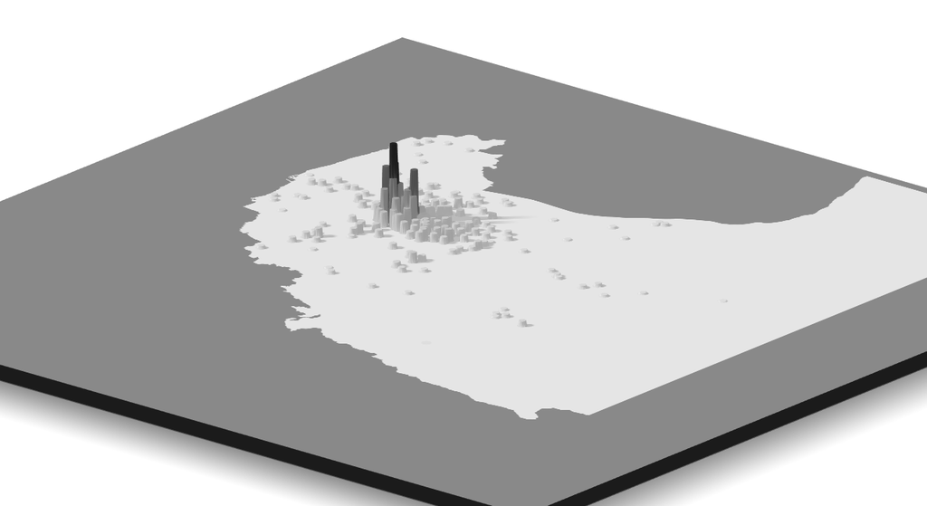

**（B）方位角＝270，余緯度＝0**

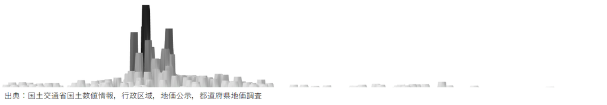

図1：富山市の土地価格分布（2022年）

このことを再確認したのが図$2$の散布図です．図$2$では，富山駅を中心地（$0$km）として，各調査地点との距離を計算し，地価と距離の組み合わせを点でプロットしています．図$2$に示された曲線は，データの近くを通り，かつ平滑になるように描かれていますが，中心地に対して内側にふくらんでいるのが特徴です．単一中心都市モデルは，この曲線で示される土地価格の様子も描写できるモデルです．注意が必要なのは，これから考えるモデルで理論的導出される土地価格は所有価格である地価ではなく，賃貸価格である地代になることです．ただし，**[住宅価格と住宅政策](https://shinichiro-iwata.github.io/lecture-notes-urban-econ/housing-price-and-policy)**第$6$節（$2$）でも述べたように，地価は地代に比例するため，地代の形状と地価の形状は同じになります．

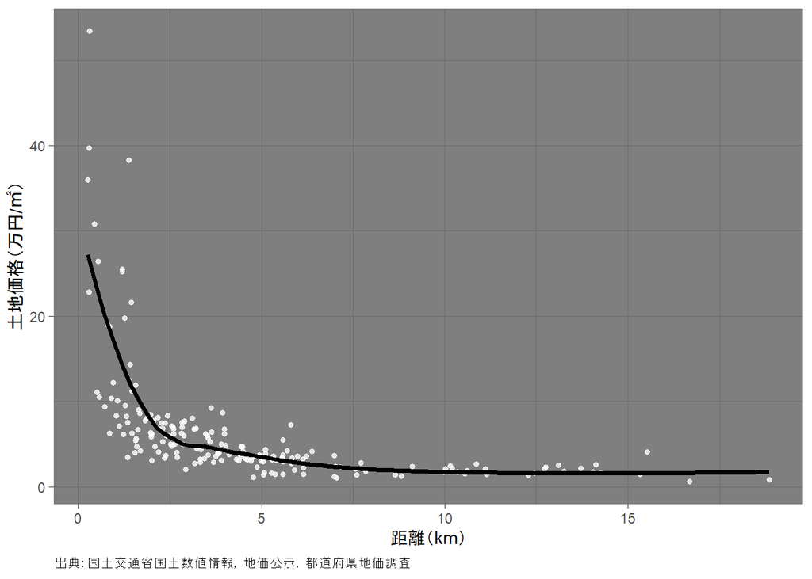

図2：土地価格の散布図と近似曲線

# 2 消費者行動の基本

消費者の住宅立地の選択は，ミクロ経済学で学ぶ消費者行動の理論を応用して考えることができます．そこで，第$2$節では住宅立地の選択を考慮しないモデルを描写し，第$3$節で住宅立地の選択を考慮した拡張モデルを紹介します．

消費者は二つの財，住宅の敷地面積$h$とその他の消費財の集合$z$，の消費量を決定するとしましょう．ただし，その他の消費財は消費量ではなく消費額で表現します．消費者は敷地面積$h$（例えば，$h$平米）の支出とその他の財の消費額$z$を所得$y$でまかなうとします．住宅の敷地面積の単位価格（地代）を$r$と表すと，消費者の**予算制約式**は$(\ref{bc})$式のように表現できます．

$$y=z+rh \label{bc}\tag{1}$$
$(\ref{bc})$式をその他の財の消費額$z$について解くと，$(\ref{z})$式を得ます．

$$z=y-rh \label{z}\tag{2}$$
縦軸に$z$，横軸に$h$をそれぞれとり，$(\ref{z})$式を描くと，図$3$のように，縦軸の切片が$y$，傾きがマイナス$r$の右下がりの直線で予算制約線を描くことができます．したがって，予算制約線の傾きの絶対値は**地代**$r$に等しくなります．

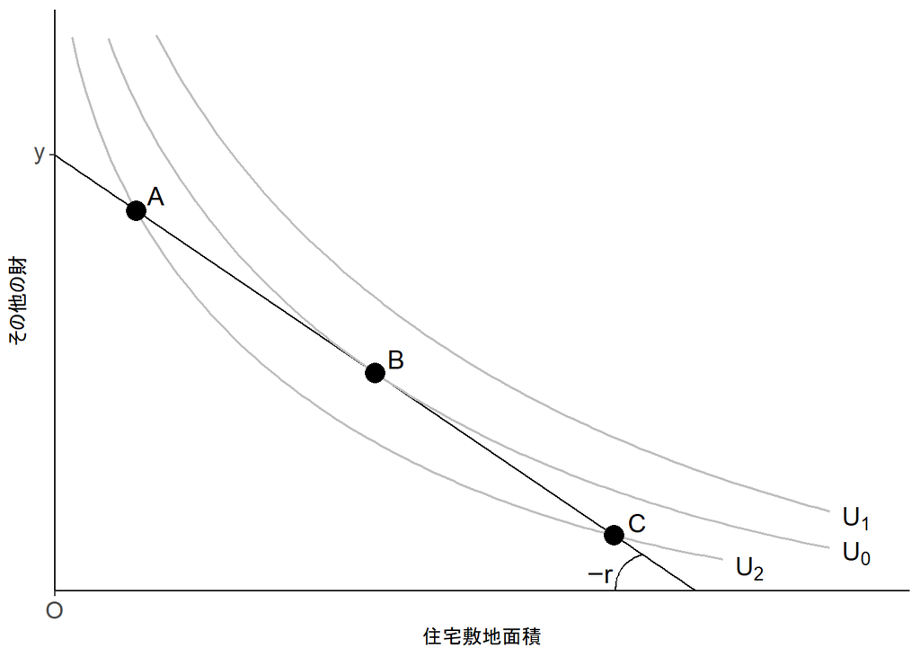

図3：消費者行動の基本モデルの最適均衡

消費者はこの予算制約線上のどの消費の組み合わせも選択できます．そして，その組み合わせの中で最も満足，効用，が高くなる組み合わせを選択します．それでは，どの組み合わせがその条件を満たすのでしょうか？これを理解するために，図$3$に消費者の住宅敷地面積の消費とその他の財の消費額に対する選好を示す**無差別曲線**（$U_2$，$U_0$，$U_1$）を重ねています．無差別曲線とは，消費者の効用が等しくなる，すなわち選好が無差別になる，消費の組み合わせを結んだ曲線をさします．無差別曲線は，平面の地図上で土地の高さを表現する等高線（同じ高さの点を結んだ線）の考えを消費者の選好にあてはめたと考えるとわかりやすいでしょう．消費者行動の理論では，消費者の選好に序列をつけられると考えています．ここでは，例えば無差別曲線$U_0$は効用水準が$U_0$であることを表しています．

消費量の効用は消費量が多いほど高くなると仮定しましょう．いま，無差別曲線$U_0$の任意の点から，敷地面積の消費量を増加させ，その他の財の消費額を変えないとしましょう．このとき，当初の消費の組み合わせと，敷地面積消費量が多い変化後の消費の組み合わせでは，変化後の消費の組み合わせを選択したほうが消費者の効用は高くなるはずです．変化後の組み合わせは，例えば異なる無差別曲線$U_1$上に存在することになります．$U_1$は$U_0$より高いため，右側（または上側，右上側）に位置する無差別曲線ほど高い効用を消費者にもたらします．このことは，敷地面積の消費量が増えたときには，それに伴う効用の上昇を相殺するように，その他の財の消費額が減らなければ，効用を一定に保てないことを意味します．これが，無差別曲線が右下がりになる，すなわち無差別曲線の傾きが負になる，理由です．ここで，無差別曲線の傾きは，曲線上の任意の点に対して接線を引き，その接線の傾きの大きさを測ることによって求まります．この接線の傾きは，消費者が敷地面積の消費量を追加的に$1$単位増やしたときに，同一の効用に留まるために，あきらめてもよいと思うその他の財の消費額の減少量（ここでは，額）になり，その絶対値は**限界代替率**とよばれます．

消費者は一方の財が極端に多く，他方の財が極端に少ない消費の組み合わせに対して，できればバランスのとれた消費の組み合わせを選好します．無差別曲線上を右下に移動すると，敷地面積の消費量は多くなりますが，反対にその他の財の消費額が少なくなります．このため，住宅敷地面積の消費量が増加するにつれて，消費者はあきらめるその他の財の消費額を抑えること（限界代替率を小さくすること）で，消費のバランスを保とうとします．無差別曲線が，原点に対して内側にふくらむ曲線になるのは，限界代替率が一定ではなく，このように次第に小さくなっていくことを反映しています．

図$3$から，予算制約上に$A$点，$B$点，$C$点の消費の組み合わせが示されています．この中で$B$点を通る無差別曲線は，$A$点と$C$点を通る無差別曲線に比べて右側に位置するため効用が高い．実際に，予算を制約とした消費者の効用最大点は$B$点になります．$B$点では，消費者の無差別曲線と予算制約線が接しています（限界代替率と地代が等しくなっています）．それに対して，$A$点と$C$点では，無差別曲線が予算制約線と交差しています（限界代替率と地代が異なっています）．消費者は$A$点から予算制約線上を右下の点に，または$C$点から予算制約線上を左上の点に消費の組み合わせを変更することで，より高い効用をもたらす無差別曲線に移動できます（$U_2$と$U_0$の間には，$U_2$より効用が高いが，$U_0$より効用が低い効用をもたらす無差別曲線が存在しますが，図が煩雑になるため描いていません）．そして，このような効用を高める移動は無差別曲線が予算制約線と接するまで続きます．一方，消費者はさらに高い効用を求めて，例えば無差別曲線$U_1$上に移動することはできません．なぜなら，無差別曲線$U_1$は予算制約線より右側に位置するため，$U_1$上のどの消費の組み合わせも与えられた消費者の予算を超えているからです．

# 3 住宅立地選択

基本モデルでは，消費者は予算制約の下で住宅敷地面積の消費量とその他の財の消費額を効用が最大になるように決定しました．第$3$節では，単一中心都市内の住宅立地点（居住地）に関する意思決定を消費者行動の基本モデルに加えていきます．単一中心都市では，消費者は仕事（や買い物）のために中心地に通う必要があります．そこで，中心地からの距離を$x$（例えば，$x$km）と表します．単位距離当たりの（往復）交通費を$t$と表すと，$x$地点に住宅立地した消費者は中心地に通うために$tx$の交通費を負担する必要があります．この結果，消費者の予算制約式は$(\ref{bc})$式から$(\ref{tx})$式のように変更されます．

$$y-tx=z+rh \label{tx}\tag{3}$$

$(\ref{tx})$式の左辺（$y-tx$）は交通費抜きの**可処分所得**（または**純所得**）です．この可処分所得を用いて，消費者はその他の財の消費額と住宅敷地の支出をまかなうことになります．

予算制約線を図に描くために，仮に消費者が選択した住宅地が$x_b$地点であったとします．$(\ref{tx})$式の$x$に$x_b$を代入して，$z$について解くと，$(\ref{z2})$式を得ます．

$$z=y-tx_b-rh \label{z2}\tag{4}$$

第$2$節と異なるのは，図$4$のように，縦軸の切片が所得$y$から可処分所得$y-tx_b$に変更された点です．図$3$同様，予算制約線の傾きの絶対値は地代$r$に等しくなり，消費者は$B$点で効用が最大になります．

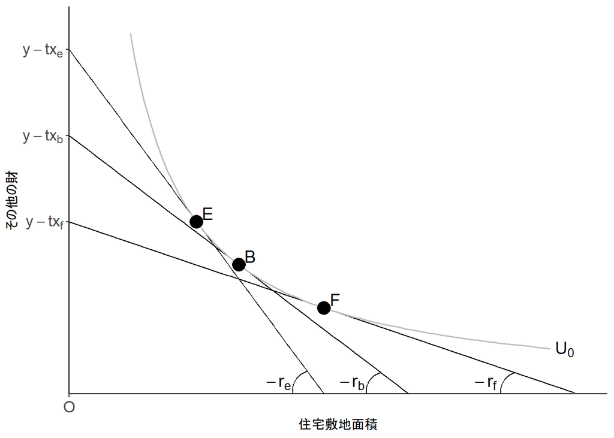

図4：住宅立地モデルの最適均衡

しかし，消費者は都市内の立地点を自由に決めることができます．仮に，都市内の他の地点に住宅を構えた方が高い効用を達成できるのであれば，$x_b$地点ではなくその地点を選ぶでしょう．最終的に選択した地点における効用水準を考えるには，**立地均衡**における効用水準を考えることが有用になります．ここで，立地均衡とは，都市に居住するどの消費者も選択した地点から別の地点に移動することによって効用を高めることができない状態をいいます．簡単化のため，都市に居住するすべての消費者は同質的である（すべての消費者の選好，所得，単位距離当たり交通費が等しい）としましょう．消費者が同質的なとき，都市内のすべての立地点で効用は等しくなります．なぜなら，どこに移動しても同じ効用であれば，立地点を変更する理由は見つかりません．一方で，都市内で効用格差が生じている場合は，高い効用を求めて消費者は立地点を変えるため，均衡条件を満たしません．

消費者が$x_b$地点を選択したときに，$U_0$の効用水準を達成するためには地代$r_b$を用意しなければなりません．地代$r_b$を支払うことで，$B$点の消費の組み合わせを選択できます．地代$r_b$より低い地代では，効用が$U_0$より高くなるため，消費者間の競争により，$x_b$地点には立地できません．また，均衡では$U_0$より高い効用は達成できないため，$x_b$地点において地代$r_b$より高い地代を支払っても仕方がありません．この意味で，地代$r_b$は$U_0$の効用を$x_b$地点において達成するために消費者が用意できる最高地代になります．これを**付け値地代**とよびます．

逆に，消費者が$x_b$地点より中心地に近い$x_e$地点を選択したとしましょう．ここで，後の議論のために，$x_f$地点と$x_b$地点の距離の差と$x_b$地点と$x_e$地点の距離の差は等しいことにします．このとき，消費者は付け値地代を$r_e$に上昇させ，$E$点を選択します．その結果，$E$点は$B$点に比べて，住宅敷地が減少し，代わりに他の消費額が増えています．交通費が低い都心近郊では，付け値地代を引き上げないと立地できません．住宅敷地は小さくなりますが，効用を一定に保つように，その他の財の消費を楽しんでいることわかります．

これまでの分析で理解できたことは，消費者は同質的にもかかわらず，立地点で消費の組み合わせが異なることです．これは付け値地代が異なることに関係しています．

# 4 付け値地代曲線

それでは，付け値地代曲線はどのような形状になるでしょうか．図$5$は，縦軸に付け値地代$r$，横軸に中心地からの距離$x$をそれぞれとり，消費者の効用を一定とする付け値地代曲線$r_0$を描いています．$B'$点，$E'$点，$F'$点は，図$4$の$B$点，$E$点，$F$点に対応して描かれています．図$4$で見たように，中心地から離れる（交通費がかかる）ほど，消費者は効用を維持するために付け値地代を低下させます．これが，付け値地代曲線が右下がりになる理由です．

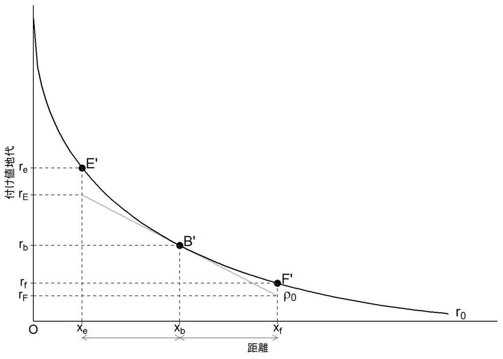

図5：付け値地代曲線

興味深いことに，付け値曲線は直線的に下落せず，図$2$同様に，中心近くで急に下がり，郊外では緩やかに下がっていきます．すなわち，付け値地代曲線は原点に対して内側にふくらんでいます．

この謎を八田（$1992$）にならい解明しましょう．そこで消費者は，立地点にかかわらず，すべての立地点で中間地点$x_b$と同じ消費の組み合わせ（$h_b$，$z_b$と表すことにします．）を選択していると仮定します．このとき，$x_e$地点，$x_b$地点，$x_f$地点を選択する消費者の予算制約線は次のようになります．

$$y-tx_e=r_Eh_b+z_b \label{E}\tag{5}$$
$$y-tx_b=r_bh_b+z_b \label{B}\tag{6}$$
$$y-tx_f=r_Fh_b+z_b \label{F}\tag{7}$$
ここで，$r_E$は$x_e$地点に立地し，かつ図$3$の$B$点（住宅敷地面積の消費量を$h_b$，その他の消費財の消費額を$z_b$ とします）の消費の組み合わせを選択したときの地代を，$r_F$は$x_f$地点に立地し，かつ$B点$の消費の組み合わせを選択したときの地代をそれぞれ示しています．

$(\ref{E})$式から$(\ref{B})$式を差し引くと$(\ref{s})$式を，$(\ref{B})$式から$(\ref{F})$式を差し引くと$(\ref{f})$式を得ます．
$$t(x_b-x_e)=-(r_b-r_E)h_b \label{s}\tag{8}$$
$$t(x_f-x_b)=-(r_b-r_F)h_b \label{f}\tag{9}$$

$(\ref{s})$式の左辺は，$x_e$地点から$x_b$地点に立地点を変更したことによる交通費の増加額を示しています．それに対して，$(\ref{s})$式の左辺の括弧内は，$x_e$地点から$x_b$地点に立地点を変更したときの地代の引き下げ幅を示しています．消費者は交通費が増加した分，地代を引き下げようとします．同様に，$(\ref{f})$式の左辺は，$x_b$地点から$x_f$地点に立地点を変更したことによる交通費の増加，右辺の括弧内は，$x_b$地点から$x_f$地点に立地点を変更したときの地代の引き下げ幅をそれぞれ示しています．

ここで，$x_e$地点と$x_b$地点の距離の差と$x_b$地点と$x_f$地点の距離の差は等しかったことを思い出してください．このことは，$(\ref{s})$式の左辺の大きさと$(\ref{f})$式の左辺の大きさは等しいことを意味します．$(\ref{s})$式の右辺と$(\ref{f})$式の右辺の敷地面積が等しいことに注意すると，$(\ref{s})$式の右辺の括弧内と$(\ref{f})$式の右辺の括弧内の大きさも等しくなります．すなわち，$x_b$地点から$x_e$地点に立地点を変更したときの地代の上昇幅と，$x_b$地点から$x_f$地点に立地点を変更したときの地代の低下幅が等しくなるため，これを満たす地代曲線は図$5$の$\rho_0$ような直線になります．

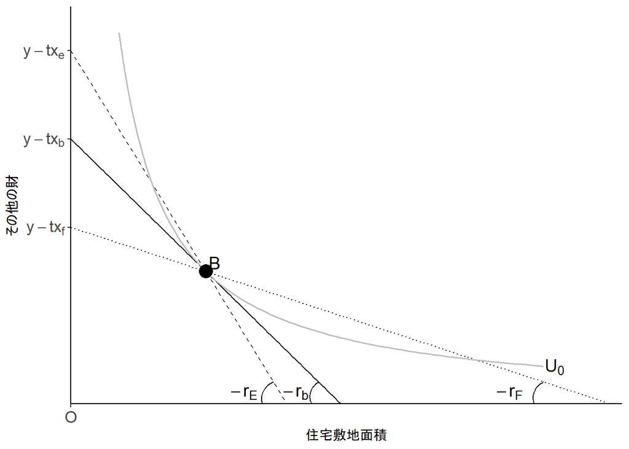

図6：付け値地代曲線が直線の場合

土地を供給する地主は，収入をできるだけ大きくしようと，最も高い地代を支払う消費者に土地を与えるのが理にかなった行動と考えられます．仮に消費者が$N$（例えば，$N$人）存在するとしましょう．このとき，住宅敷地を需要しようとする$N$の消費者は，任意の地点の土地に対して最終的にどのような価格付けをするでしょうか．同質的な消費者の仮定の下では，すべての消費者の付け値曲線は図$5$のそれと同じ形状です．したがって，任意の地点における最高地代は図$5$の付け値地代に等しくなります．他のすべての地点においても同じことがいえるため，$N$の消費者が任意の土地に対して支払える最高地代は図$5$の付け値曲線から求めることができます．この付け値曲線の形状は，図$2$で実際に観察される住宅敷地の地価の分布の特徴を捉えていると考えられます．

# 5 市場地代曲線と都市の土地利用

住宅地以外の土地利用として農地を考えてみましょう．農地は，土地を利用できれば，農産物を生産でき，農家は中心地からの距離と関係なく，一定の地代で土地を利用したいと考えているとしましょう．この農業地代（農家の付け値地代）を描いたのが図$7$の水平な直線$r_0^A$です．

第$4$節で述べたように，地主はできるだけ高い地代を支払う用意のある主体に土地を提供します．したがって，土地は中心地から$\bar{x}_0$地点までは$N$の消費者に対して住宅地として提供され，$\bar{x}_0$地点から先は農家に対して農地として提供されるようになります．都市の大きさは中心地から$\bar{x}_0$地点までの住宅地で測られ，$\bar{x}_0$地点を**都市の境界**とよびます．

市場地代曲線$R_0$は，最高地代をなぞることになるため，中心地から$\bar{x}_0$地点までは消費者の付け値曲線$r_0$に，$x_0$地点から先は農業地代$r_0^A$に一致します．

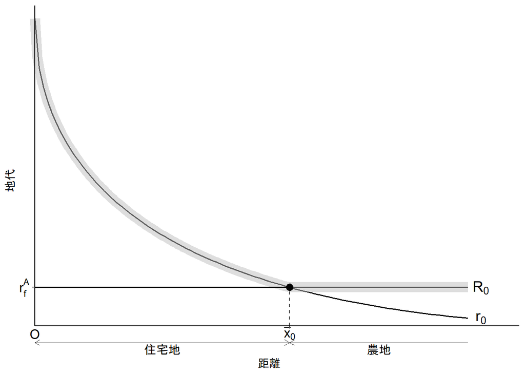

図7：市場地代曲線と都市の土地利用

# 6 都市の変化

単一中心都市モデルでは，中心地から都市の境界の範囲で都市を表現します．都市が決定すれば，人口と都市の境界から都市全体の人口密度を知ることができます．ただし，都市（の土地利用）や人口密度は市場地代曲線の形状やその位置に依存します．したがって，市場地代曲線の形状や位置が変化（シフト）すれば都市も変化します．この結果，人口密度も変化することになります．そこで，第$6$節では市場地代曲線が変化する要因を考え，都市がそれに伴いどのように変化するのかを考えましょう．この分析は，過去に比べて現在の都市がなぜ異なり，将来どのように変化するのか（都市内の時系列分析），ある都市と他の都市がなぜ違うのか（都市間の横断面分析）を考える手がかりになります．

## （1）単位距離当たり交通費の低下

図$8$において，当初の立地均衡における効用水準が$U_0$で表されたとしましょう．このとき，$x_0$地点に立地する消費者の付け値地代は$\alpha_0$に，$x_0$地点より郊外の$x_1$地点に立地する消費者の付け値地代は$\alpha_1$になります．ここで，単位距離当たりの交通費が$t_0$から$t_1$に低下すると，いずれの立地点においても消費者の可処分所得は，交通費低下前よりも上昇するため，予算制約線は右方（または上方）シフトします（ただし，中心地に立地する消費者は，可処分所得が変わらないため，予算制約線の縦軸の切片は変わりません）．この右方シフトの結果，すべての消費者はより高い効用をもたらす無差別曲線$U_1$に移動できます．図$8$では，$x_0$地点に立地する消費者の付け値地代は$\beta_0$に，$x_1$地点に立地する消費者の付け値地代は$\beta_1$に変化します．図$8$から，中心地に近い$x_0$地点の交通費低下後の付け値地代$\beta_0$は，低下前の付け値地代$\alpha_0$よりも低くなっています．一方，郊外の$x_1$地点の交通費低下後の付け値地代$\beta_1$は，低下前の付け値地代$\alpha_1$よりも高くなっています．住宅敷地面積は所得が上昇すると増加し（これを，**上級財**または**正常財**とよびます），地代が低下しても増加するとしましょう．図$8$では，中心地に近い$x_0$地点では，実際に可処分所得が上昇し，付け値地代が低下するため，敷地面積の消費量が増加しています．郊外では可処分所得は上昇しますが，付け値地代も上昇するため，敷地面積の消費量への影響は確定しません．図$8$では，郊外の$x_1$地点において消費者の敷地面積の消費量が増える場合が描かれています．

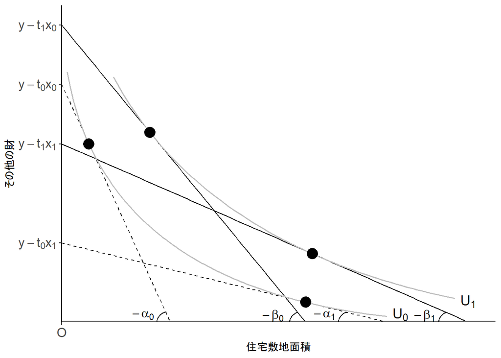

図8：交通費の低下と最適点の変化

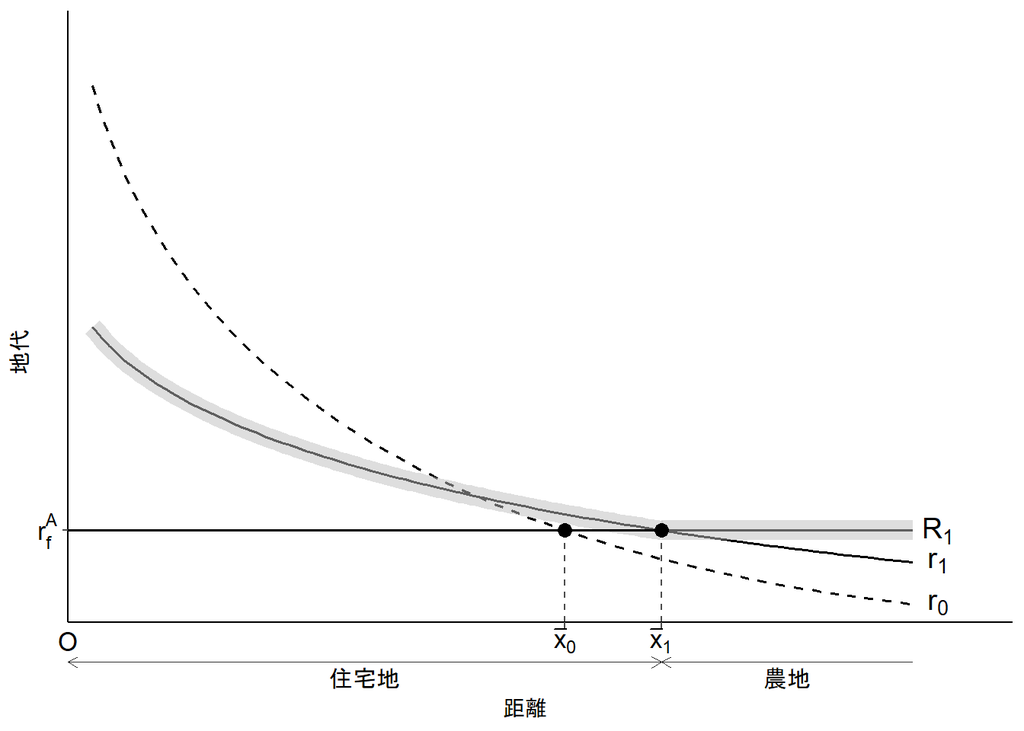

図9：交通費の低下と所得の上昇が都市の土地利用に与える影響

## （2）所得の上昇

図$10$において，当初の立地均衡における効用水準が$U_0$で，単位距離当たりの交通費が$t$で表されたとしましょう．このとき，$x_0$地点に立地する消費者の付け値地代は$\alpha_0$に，$x_0$地点より郊外の$x_1$地点に立地する消費者の付け値地代は$\alpha_1$になります．ここで，消費者の所得が$y_0$から$y_1$に上昇すると，いずれの立地点においても，予算制約線は右方（または上方）シフトします．この右方シフトの結果，すべての消費者はより高い効用をもたらす無差別曲線$U_1$に移動できます．図$10$では，$x_0$地点に立地する消費者の付け値地代は$\beta_0$に，$x_1$地点に立地する消費者の付け値地代はは$\beta_1$に変化します．図$10$から，中心地に近い$x_0$地点の所得上昇後の付け値地代$\beta_0$は，上昇前の付け値地代$\alpha_0$よりも低くなっています．一方，郊外の$x_1$地点の所得上昇後の付け値地代$\beta_1$は，上昇前の付け値地代$\alpha_1$よりも高くなっています．中心地近くでは所得の上昇と付け値地代の低下によって，敷地面積の消費量は増加します．郊外では，付け値地代も上昇するため，敷地面積の消費量への影響は確定しませんが，図$10$の場合，郊外の$x_1$地点では敷地面積の消費量が増える場合が描かれています．以上から，所得の上昇が第$6$節（$1$）で分析した単位当たりの交通費の低下と定性的に等しい変化を引き起こしていることがわかります．

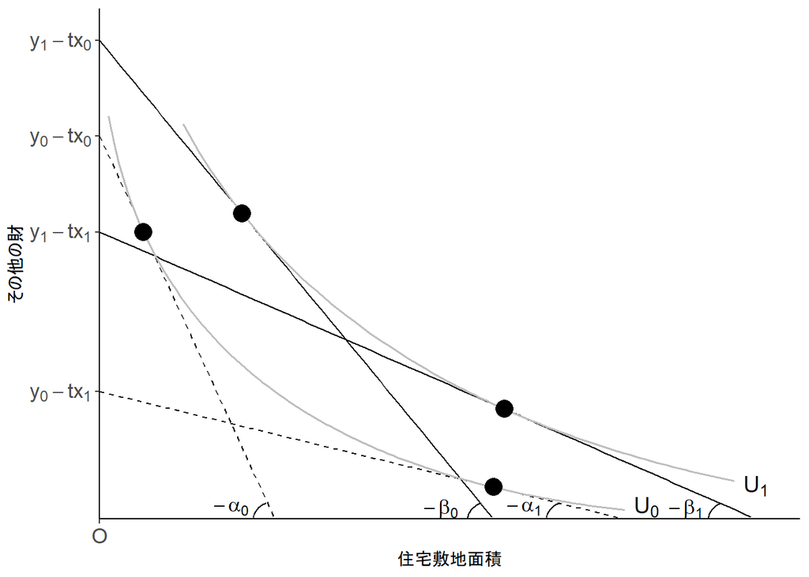

図10：所得の上昇と最適均衡の変化

所得が上昇すると，消費者は広い土地を求めて郊外を選好するようになります．この結果，図$10$で見たように中心地近くでは消費者の付け値地代が低下し，郊外ではそれが上昇します．これを反映して，図$9$の単位当たりの交通費が低下した場合と同様に，所得上昇後の付け値地代曲線$r_1$は上昇前の付け値地代曲線$r_0$と交差するようにシフトします．付け値地代曲線と農業地代の交点で決定する都市の境界は$\bar{x}_0$地点から$\bar{x}_1$地点へと右に移動し，郊外化が進展します．市場地代曲線は太線$R_1$に変化します．人口が変化せず，都市の境界が右に移動するため，都市全体の人口密度は低下します．

## （3）農業地代の低下

説明を容易にするために，付け値地代曲線のシフトから説明しましょう．農業地代が低下した場合，農業地代を示す水平線は図$11$の$r_0^A$から$r_1^A$のように下方にシフトします．もし，付け値地代曲線が変化しなければ，新しい農業地代ともとの付け値地代曲線の交点で決定する都市の境界は右側に移動します．しかし，消費者の敷地面積の消費量がもとの水準と等しければ，空き地が生まれ，住宅敷地の超過供給が生じます．このことは，消費者が以前より低い地代を支払うことで敷地面積を消費できることを意味するため，農地地代の低下に伴って，付け値地代曲線も$r_0$から$r_1$のように下方シフトします．付け値地代の低下は，消費者の敷地面積の消費量の増加を意味します．都市の人口は一定のため，消費者が都市に立地するためには，都市の境界は$\bar{x}_0$地点から$\bar{x}_1$地点へと右に移動し，郊外化が進展しなければなりません．市場地代曲線は太線$R_1$のように変化します．人口が変化せず，都市の境界が右に移動するため，都市全体の人口密度は低下します．

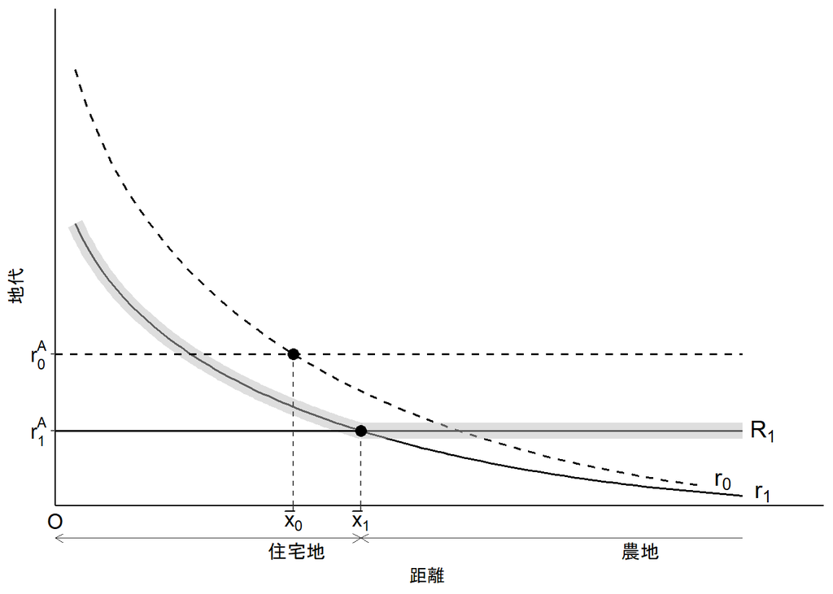

図11：農業地代の低下が都市の土地利用に与える影響

図$12$において，当初の立地均衡における効用水準が$U_0$であれば，$x_0$地点に立地する消費者の付け値地代は$\alpha_0$に，$x_0$地点より郊外の$x_1$地点に立地する消費者の付け値地代は$\alpha_1$になります．農業地代が低下すると，すべての消費者はより高い効用をもたらす無差別曲線$U_1$に移動でき，$x_0$地点に立地する消費者の付け値地代は$\beta_0$に，$x_1$地点に立地する消費者の付け値地代は$\beta_1$に，それぞれ農業地代低下前よりも低下します．可処分所得は変化しませんが，付け値地代が低下するため，すべての地点で消費者の敷地面積の消費量は増加します．

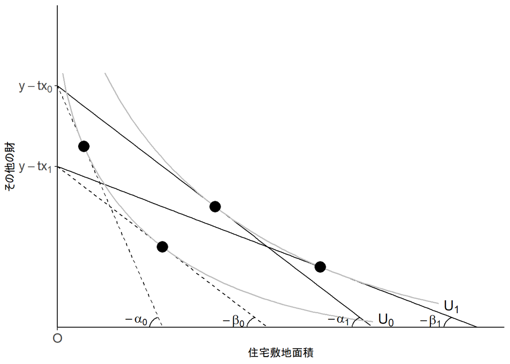

図12：農地地代の低下と最適均衡の変化

# 7 郊外化とその問題点

日本の地方都市は，人口密度の低下が問題視されています．図$13$は$1975$年から$10$年毎にみた富山市の$\rm{DID }$地区の変遷です．時間とともに$\rm{DID }$地区が郊外に向かって拡大する様子がうかがえます． $\rm{DID }$地区の境界を都市の境界と考えると，郊外化が進んでいると考えられます．富山市ではこの$\rm{DID }$地区の拡大は人口の拡散を招きました．すなわち，$\rm{DID }$地区の人口密度は$1975$年の約$5205$人/$\rm{km}^2$ら$2005$年の約$4029$人/$\rm{km}^2$へと$22.6$％も減少したのです．

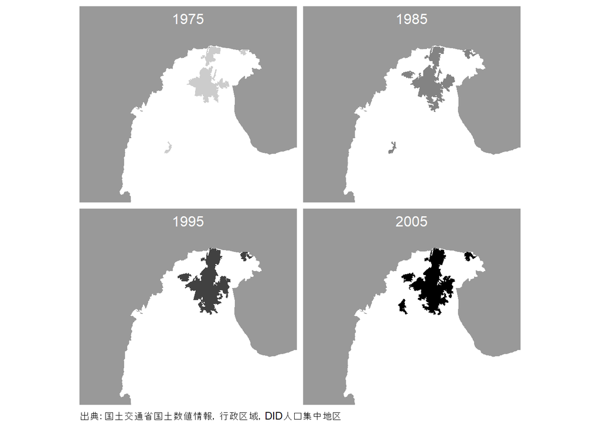

図13：富山市のDID地区の変遷

このような人口密度の変化は地価の変化にも表れます．$1997$年から$2007$年にかけて，日本全国にかけて地価は下落傾向でした．図$14$の富山市（破線は鉄道・軌道）について注目すると，その影響は中心地で相対的に大きく，郊外で相対的に小さいことがうかがえます．このことは消費者が中心地近くを選好する理由が弱くなったことを示唆します．

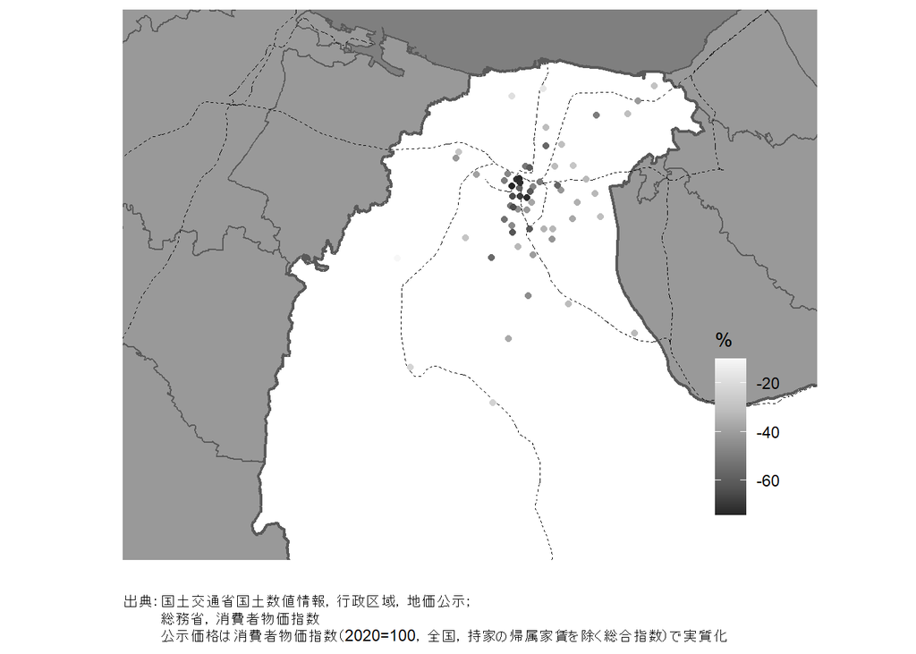

図14：1997年から2007年の富山市の公示価格変化率

第$6$節で見たように，郊外化や人口密度の低下は，交通費の低下，所得の上昇，農業地代の低下が要因になります．例えばガソリン価格の低下，道路の整備・改善，低燃費車の普及は，都心までの移動を容易にし，交通費を実質的に低下させます．地方都市では，地方政府を中心に郊外の道路を整備・改善し，着実に都市内の自動車移動を容易にしてきたと考えられます．地方都市に限りませんが，インターネット通信の普及は，在宅勤務や通信販売の機会を飛躍的に拡大しました．このことは消費者にとって中心地に向かう回数を減らし，交通費の実質的な低下をもたらします．この影響が，地方都市では大きかったのかもしれません．

地方都市の中には，一人当たりの所得は低くても，世帯人数の多さや有業率の高さを反映して，世帯当たりの所得が高い例が存在します．所得が高いと，家計は広い住宅を求めて郊外を選好します．実際に，地方都市では郊外に大きな敷地を持つ住宅が建ち並ぶ様子がうかがえます．

さらに，農業従事者の担い手不足，高齢化や後継者不足によって，地方都市の農業の生産性が低下し，農業地代の下落を招いたと考えられます．

単一中心都市モデルでは，上記の$3$つの要因から引き起こされる郊外化や人口密度の低下は消費者の効用の上昇をもたらします．したがって，郊外化の抑制や人口密度の上昇を目指す政策は，消費者の立場からは賛同を得られないでしょう．それでは，なぜ地方政府はこのような政策を取り入れるのでしょうか？

次に，自動車利用による大気質汚染を考えましょう．消費者は大気質汚染によって他の主体の厚生が悪化することを考慮しないで，自動車を利用して中心地に移動しているとしましょう．そこで，消費者が自動車利用する際に発生する単位距離当たりの負の外部性を，先の例と同じく$e$と表すと，$x$地点に住宅立地した消費者は，実際には外部費用$ex$だけ交通費が高くなります．図$9$において，消費者が各自の外部費用を負担しないときの付け値地代曲線が$r_1$で表され，都市の境界が$\bar{x}_1$地点であったとしましょう．このとき，都市で発生する外部費用は誰かの負担によって賄われています．消費者が外部費用を適切に負担する場合，都市の境界は$\bar{x}_0$地点のように左側に存在することになります．なぜなら，郊外ほど外部費用を含んだ交通費の負担が大きくなるため，消費者は中心地近くに立地し，その費用を節約しようとするからです．すなわち，外部費用の負担は単位当たりの交通費が上昇したときと同じ影響を与えるため，付け値地代曲線は$r_0$ようにシフトします．以上から，外部費用を適切に負わせることで，都市を縮小し，自動車の移動距離を縮め，大気質の改善につなげることができます．

# 8 都市間の人口移動

これまでは，都市の人口を一定と仮定して，分析をすすめてきました．第$6$節で見たように，単位距離当たりの交通費が低下したり，消費者の所得が増加したり，農業地代が低下したりすると，消費者の効用は上昇しました．それでは，都市の人口が変化する場合はどうなるでしょうか？すべての消費者が同質的であれば，他の都市に立地する消費者は，高い効用を求めて都市間を移動するでしょう．この結果，この都市の人口は増加するはずです．なお，都市経済学では，人口移動が認められない都市を**閉鎖都市**，認められる都市を**開放都市**とよびます．都市の人口増加はどこまで続くでしょうか？他の都市の消費者は，この都市に立地したときの効用が高い限り移動を止めません．仮に人口増加に伴いこの都市に立地する効用が低下し，この都市で達成できる効用が他の都市の効用と等しくなれば，この都市への人口流入は止まるでしょう．すなわち，開放都市の立地均衡においては，どの都市に立地しても消費者の効用は等しくならなければなりません．なお，この都市の人口が全都市人口に比べてきわめて小さいとき，都市は**小都市**とよばれます．開放都市市と小都市の二つの性質を満たす都市は**小開放都市**とよばれ，小開放都市では人口が他の都市の効用と等しくなるように決定されます．

## （1）単位距離当たり交通費の低下

図$15$において，当初の立地均衡における効用水準が$U_0$で表されたとしましょう．このとき，$x_0$地点に立地する消費者の付け値地代は$\alpha_0$になります．ここで，単位距離当たりの交通費が低下すると，消費者の可処分所得が上昇するため，予算制約線の縦軸の切片は$Y_0$から$Y_1$へと上方に移動します．第$6$節（$1$）で見た閉鎖都市では，交通費の低下に伴い，いずれの立地点においても，予算制約線は右方（または上方）シフトし，消費者はより高い効用をもたらす無差別曲線に移動できました（図$8$）．しかし，小開放都市では，人口移動に伴って，効用水準が$U_0$より高くはなりません（$U_0$にとどまる）．図$15$では，消費者は$x_1$地点に対して付け値地代$\alpha_1$を用意しています．これは，人口増加に伴い敷地需要の競争が増すため，消費者はより高い地代を用意しないと，同じ地点に立地し続けることができないことを意味します．その結果，交通費が低下すると，今までより少ない敷地面積の消費しかできなくなります．

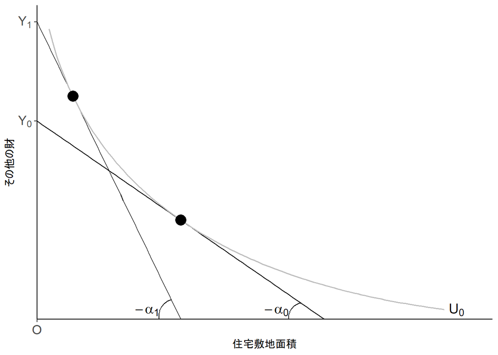

図15：小開放都市における交通費の低下，所得の上昇と最適点の変化

中心地を除く他の立地点においても同じことがいえます．中心地は可処分所得が変わらないため，予算制約線の縦軸の切片，付け値地代，敷地消費面積は，交通費低下の影響を受けません．したがって，図$16$に示すように，交通費低下後の付け値地代曲線$r_1$は低下前の付け値地代曲線$r_0$と中心地で等しくなりますが，その他の立地点では上方に位置することになります．付け値地代曲線と農業地代の交点で決定する都市の境界は$\bar{x}_0$地点から$\bar{x}_1$地点へと右に移動し，交通費低下に伴い郊外化が進展します．市場地代曲線は太線$R_1$のようになります．交通費が低くなると，人口が増加し，都市の境界は右に移動しますが，中心地を除いて，消費者一人ひとりの敷地消費量が減少するため，都市全体の人口密度は上昇します．

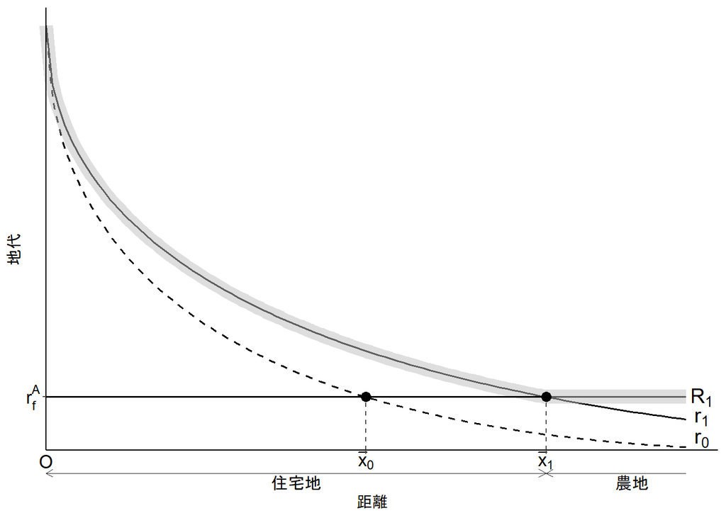

図16：小開放都市における交通費の低下が都市の土地利用に与える影響

## （2）所得の上昇

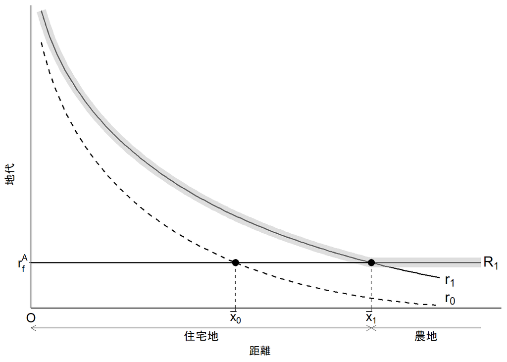

図17：小開放都市における所得の上昇が都市の土地利用に与える影響

## （3）農業地代の低下

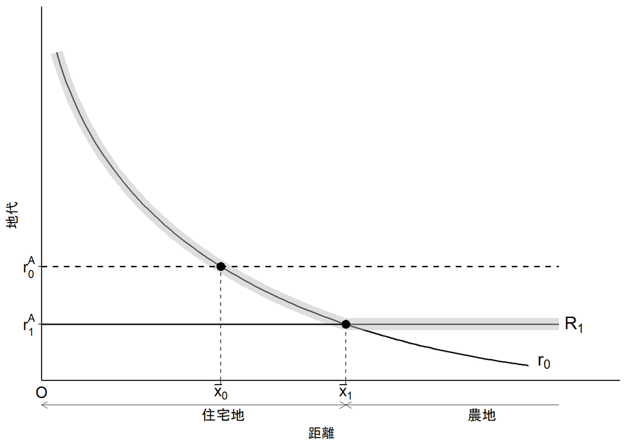

図18：小開放都市における農業地代の低下が都市の土地利用に与える影響

# 9 まとめと練習問題，自主研究へのヒント

**まとめ**

**練習問題**

1. 日本の企業は通勤費を通勤手当として所得以外で負担しています．これは，通勤手当が所得税の課税対象とならない場合があるため，所得ではなく通気手当という形で金銭を受け取ったほうが家計にとって都合が良い場合があるからです．そこで，通勤手当が人々の住宅立地にどのように影響しているかを考えてください．
2. 本文では消費者は同質と仮定していましたが，高所得者と低所得者が存在する場合の各々の付け値地代曲線はどのような形状になり，それによって土地利用はどのようになるかを考えてください．
3. 本文では単一中心都市における消費者の付け値地代曲線を考えました．いま，都市から$x_0\rm{km}$離れたとところに副都心が出現したとしましょう．このときの消費者の付け値地代曲線はどのような形状に変わり，それによって土地利用はどのようになるかを考えてください．

**自主研究へのヒント**

1. 図$2$は富山市の例ですが，皆さんが関心のある都道府県の県庁所在地（あるいはある程度大きな市）で同じように地価と中心地からの距離の関係を示してください．本文で使った，地価は[国土数値情報ダウンロードサービス](https://nlftp.mlit.go.jp/ksj/)からからダウンロード可能です．
2. 皆さんが関心のある都道府県の県庁所在地（あるいはある程度大きな市）の$\rm{DID}$地区の変遷を（i）面積，（ii）人口，（iii）人口密度に注目して調べてください．これらのデータについても[国土数値情報ダウンロードサービス](https://nlftp.mlit.go.jp/ksj/)からダウンロード可能です．

**今後の学習**

ここでは扱わなかった発展内容について扱っているテキストを紹介します．

大都市の中には中心地以外にも職場（副都心）が存在します．地方都市では郊外にショッピングモールが形成され，中心市街地に立地する商店街と競争しています．このように，職場や小売店舗が中心地以外にも存在する多核都市モデルの分析については，以下のテキストが参考になります．

- 高橋孝明（$2012$）[『都市経済学』](http://www.yuhikaku.co.jp/books/detail/9784641184060)有斐閣ブックス

このテキストでは，本文とは異なり，消費者が異質な場合の土地利用についても紹介しています．さらに，ミクロ経済学の基礎的な部分も丁寧に解説している良書です．

地価や地代の高い場所では狭い土地に高い建築物を建てる傾向にあり，逆に地代の低い場所では広い土地に低い建築物を建てる傾向にあります．このような現象を住宅メーカーや不動産デベロッパーの行動から説明しているテキストとして，次の洋書テキストが挙げられます．

- $\rm{Brueckner,}$ $\rm{Jan}$ $\rm{K}$ （$2011$）[$\rm{Lectures}$ $\rm{on}$ $\rm{Urban}$ $\rm{Economics}$](https://mitpress.mit.edu/9780262016360/lectures-on-urban-economics/), $\rm{MIT}$ $\rm{Press}$

なお，本稿はこのテキストの第$2$章（都市の空間構造の分析）と第$4$章（郊外化と土地利用規制）に大きな影響を受けています．

単一中心都市モデルに外部性の影響を取り入れた分析については，上記のテキストの他，下記のテキストが有益です．

- 金本良嗣・藤原徹（$2016$）[『都市経済学』](https://str.toyokeizai.net/books/9784492813034/)（第2版）東洋経済新報社
- 中川雅之（$2008$）[『公共経済学と都市政策』](https://www.nippyo.co.jp/shop/book/6427.html)（デジタル複製版）日本評論社

地方公共財の供給を考慮した単一中心都市モデルについては，下記のテキストに詳しく分析されています．

- $\rm{Fujita,}$ $\rm{Masahisa}$（$1989$）[$\rm{Urban}$ $\rm{Economic}$ $\rm{Theory}$: $\rm{Land}$ $\rm{Use}$ $\rm{and}$ $\rm{City}$ $\rm{Size}$](https://www.cambridge.org/core/books/urban-economic-theory/1787328AC538E75129273E8B54A161FC), $\rm{Cambridge}$ $\rm{University}$ $\rm{Press}$

このテキストは本文の内容を厳密に分析している大学院レベルのテキストになります．

# 参考文献

- 八田達夫（$1992$）[「巨大都市の経済学$3$：集積の利益と通勤費」](https://cir.nii.ac.jp/crid/1523388079607686656)『経済セミナー』$449$号$\rm{pp.}76-82$
- $\rm{OECD }$（$2013$）[$\rm{Compact}$ $\rm{City}$ $\rm{Policies:}$ $\rm{A}$ $\rm{Comparative}$ $\rm{Assessment}$ $\rm{(Japanese}$ $\rm{version)}$](https://dx.doi.org/10.1787/9789264180314-ja) （[『コンパクトシティ政策 : 世界$5$都市のケーススタディと国別比較』](https://ci.nii.ac.jp/ncid/BB13584608?l=ja)）$\rm{OECD}$ $\rm{Publishing}$

# 補論（Rによるデータ分析）

## 市場地価曲線の推定

これまで市場地代曲線は右下がりで原点に対して内側にふくらむ付け値地代曲線を反映した形状になることを理論的に学びました．ここでは，このことを実際のデータ（都道府県地価調査）を用いて推定してみましょう．国土交通省は[国土数値情報ダウンロードサービス](https://nlftp.mlit.go.jp/ksj/)というウェブサイトで，シェープファイル形式でこのデータを開示しています ．シェープファイル形式はデータ属性に地理空間情報が付されているのが特徴です．[^1]これにより，地図上にデータを可視することが容易になります．以下では富山市を例にとって市場地価曲線を推定します．そこで，このサイトから**`都道府県地価調査（ポイント）`**，**`富山県`**，**`「富山県」データのダウンロード`**，**`富山　世界測地系　令和4年　0.18MB　L02-22_16_GML.zip`**の順番にクリックしてください．ダウンロードしたファイルは例えば`R`を作業するフォルダー（ディレクトリ）に格納しましょう．ファイルは圧縮されていますので，当該フォルダー内で展開しておきます．

市場地価曲線を推定するにはこの地価データ以外に中心地の位置を確定し，各調査地点と中心地からの距離を計算する必要があります．ここでは，富山市の中心地として富山市の主要駅である富山駅を選びました．富山駅の位置については地図検索サイトなどから緯度・経度（世界測地系）を調べることができます．各調査地点は地理空間情報として緯度・経度が付与されていますので，富山駅と各調査地点の距離（$\rm{m}$）を`R`の`distGeo()`関数を用いて計算することが可能になります．これで，地価を距離に回帰する準備が整います．なお，土地（住宅）の属性を用いて土地価格（住宅価格）を説明するモデルを**ヘドニックモデル**とよびます．[^2]

まず，データがきちんと整っているかを確認するために，記述統計を出力してみましょう．それでは，以下の`R`コードを`R`スクリプトに打ち込み確認ください．なお以下では，地価を万円／$\rm{m}^2$に，距離を$\rm{km}$に単位変換しています．

```r
#データ・図の作成
library(tidyverse)
#シェープファイルの読込
library(sf)
#距離の計算
library(geosphere)

#富山県の地価の読込
Toyama_lp<-
  read_sf("L02-22_16_GML/L02-22_16.shp")

#富山市（16201）の地価の選別
Toyama_lp %>%
  filter(L02_020=="16201") ->
  Toyama_shi_lp

#緯度経度の列作成（xが経度，yが緯度）
Toyama_shi_lp %>%
  mutate(x=st_coordinates(geometry)[,1],
         y=st_coordinates(geometry)[,2]) ->
  Toyama_shi_lp

#距離の計算のためxとyのみのデータ作成
Toyama_shi_lp %>%
  select(x,y) %>%
  st_set_geometry(NULL) ->
  Toyama_shi_lp_xy

#富山駅の位置（経度，緯度の順）
Toyama_station<-c(137.2132271, 36.7017294)

#距離の計算
Toyama_shi_lp %>%
  mutate(dis_m=distGeo(Toyama_station,
                       Toyama_shi_lp_xy[, c("x", "y")])) ->
  Toyama_shi_lp

#単位の変換
Toyama_shi_lp %>%
  mutate(lp=L02_006/10000, dis_km=dis_m/1000) ->
  Toyama_shi_lp

#記述統計，回帰分析の結果を表にまとめるため
library(modelsummary)

#記述統計
datasummary(Heading("地価（万円／㎡）")*lp+
              Heading("距離（km）")*dis_km ~
              Heading("平均")*Mean+
              Heading("標準偏差")*SD+
              Heading("最小値")*Min+
              Heading("最小値")*Max+
              Heading("観察数")*N,
            data = Toyama_shi_lp,
            title="表1：記述統計量")
```

表1：記述統計量

|  | 平均 | 標準偏差 | 最小値 | 最小値 | 観察数 |
| --- | --- | --- | --- | --- | --- |
| 地価（万円／㎡） | 6.68 | 8.20 | 0.58 | 54.20 | 88 |
| 距離（km） | 4.82 | 4.09 | 0.26 | 18.85 | 88 |

表$1$から，地価の平均は$6.68$万円／$\rm{m}^2$，最小値は$0.58$万円／$\rm{m}^2$，最大値は$54.20$万円／$\rm{m}^2$になります．また，富山駅からの距離の平均は$4.82\rm{km}$，最小値は$0.26\rm{km}$，最大値は$18.85\rm{km}$であることが確認できます．

いよいよ市場地価曲線の推定に進みましょう．市場地価曲線が曲線になる特徴を捉えるように，推定式は例えば$(\ref{hed})$式のような$2$次関数を考えます．

$$地価=\alpha+\beta 距離+\gamma 距離二乗+\epsilon \label{hed}\tag{10}$$

$(\ref{hed})$式右辺の係数$\beta$の符号が負に推定されると，地価は中心地から距離が離れると，低下することを意味します．一方，係数$\gamma$の符号が正に推定されると，地価の低下は，中心地から距離が離れると緩やかになることを意味します．

それでは，以下の`R`コードを`R`スクリプトに打ち込み実際に推定してください．

```r
#回帰分析（modelと名付ける）
model<-
  lm(data=Toyama_shi_lp, lp~dis_km+I(dis_km^2))

#分析結果表
modelsummary(list("地価"=model), stars=TRUE,
             coef_rename=c("(Intercept)"="切片",
                         "dis_km"="距離",
                         "I(dis_km^2)"="距離二乗"),
             gof_map=c("nobs", "r.squared"),
             title="表2：市場地価関数の推定結果")
```

表2：市場地価関数の推定結果

|  | 地価 |
| --- | --- |
| 切片 | 17.581*** |
|  | (1.609) |
| 距離 | -3.714*** |
|  | (0.555) |
| 距離二乗 | 0.176*** |
|  | (0.034) |
| Num.Obs. | 88 |
| R2 | 0.410 |

+ p < 0.1, * p < 0.05, ** p < 0.01, *** p < 0.001

推定の結果は，表$2$のようになります．この結果から，予想通り距離の係数$\beta$の符号は負に，距離二乗の係数$\gamma$の符号は正に推定されました．

図$18$は，推定された値を用いて，地価と距離の関係を示しています．図$18$の距離の範囲では市場地価曲線は右下がりで，内側に膨らむことがわかります．図$18$を得るには以下の`R`コードを`R`スクリプトに打ち込んでください．

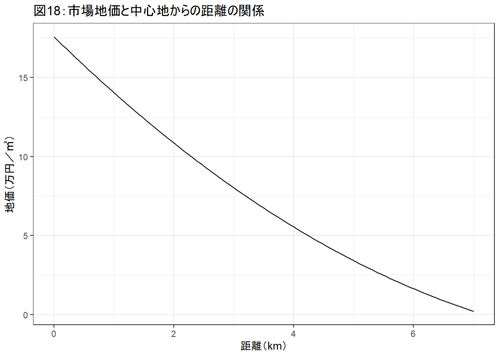

```r
#推定された市場地価関数
pred <-
  function(x)
    coef(model)[1]+coef(model)[2]*x+coef(model)[3]*x^2

#可視化
ggplot()+
  geom_function(fun=pred)+
  xlim(c(0,7))+
  labs(x="距離（km）", y="地価（万円／㎡）")+
  ggtitle("図18：市場地価と中心地からの距離の関係")+
  theme_bw()
```

# リンク

- [都市経済学講義ノート](https://shinichiro-iwata.github.io/lecture-notes-urban-econ/)
  - [住宅価格と住宅政策](https://shinichiro-iwata.github.io/lecture-notes-urban-econ/housing-price-and-policy.html)
- [Rによる地理空間データの可視化](https://shinichiro-iwata.github.io/geospatial-data-visualization/)
- [Shinichiro Iwata](https://shinichiro-iwata.github.io/)

**謝辞**

本稿を作成する上で富山大学経済学部在職時のゼミナール生佐々木悠太氏から貴重なコメントを頂戴しました．

[^1]: シェープファイルは地物・属性情報を含む複数のファイルから構成されます．拡張子は`.shp`，`.shx`，`.dbf`などになります．読み込む際は`.shp`を使いますが，ファイルから他の拡張子（`.shx`，`.dbf`など）をもつファイルを削除すると，図形・属性情報を表現できなくなります．削除しないようにしましょう．
[^2]: ダウンロードしたシェープファイルには土地の属性情報が多く含まれています．ここで作成する富山駅からの距離だけではなく，これらの属性変数を加えることで地価を説明する力は増すと考えられます．